# Multivariate Data Analysis Assignment #6

2018170865 산업경영공학부 박재현

2021. 6. 6.

```r
suppressMessages({
    library(nnet)
    library(party)
    library(caret)
    library(doParallel)
    library(ada)
    library(ipred)
    library(gbm)
    library(randomForest)
    library(bst)
    library(mboost)
    library(rpart)
    library(partykit)
    library(nnet)
    library(psych)
    library(e1071)
    library(ggplot2)
    library(NbClust) #NbClust 함수
    library(cluster) # clusplot 함수
    library(factoextra) #fviz_nbclust 함수
    library(tree)
    library(glmnet)
    library(pROC)
    library(VGAM)
    library(maboost)
    library(DMwR)
})
```

```r
data <- read.csv("Earthquake_Damage.csv", header = TRUE, stringsAsFactors=TRUE)
data <- data[,c(-1)]
input <- data[,c(-39)]
target <- data[,c(39)]
```

```r
perf_eval <- function(cm){

  # True positive rate: TPR (Recall)
  TPR <- cm[2,2]/sum(cm[2,])
  # Precision
  PRE <- cm[2,2]/sum(cm[,2])
  # True negative rate: TNR
  TNR <- cm[1,1]/sum(cm[1,])
  # Simple Accuracy
  ACC <- (cm[1,1]+cm[2,2])/sum(cm)
  # Balanced Correction Rate
  BCR <- sqrt(TPR*TNR)
  # F1-Measure
  F1 <- 2*TPR*PRE/(TPR+PRE)

  return(c(ACC, BCR))
}

perf_eval_multi <- function(cm){

    # Simple Accuracy
    ACC = sum(diag(cm))/sum(cm)

    # Balanced Correction Rate
    BCR = 1
    for (i in 1:dim(cm)[1]){
        BCR = BCR*(cm[i,i]/sum(cm[i,]))
    }

    BCR = BCR^(1/dim(cm)[1])

    return(c(ACC, BCR))
}

Perf.Table <- matrix(0, nrow = 8, ncol = 2)
rownames(Perf.Table) <- c("MLR", "CART", "ANN", "Bagging CART" ,"Bagging ANN",
                          "Random Forests","AdaBoost", "GBM")
colnames(Perf.Table) <- c("Accuracy", "BCR")
```

## [사전 작업 사항]

### [1] 입력 변수의 속성이 numeric이 아닌 변수들에 대해 1-of-C coding (1-hot encoding) 방식을 통해 명목형(요인형) 변수를 범주의 개수만큼의 이진형(binary) 변수들로 구성되는 dummy variable을 생성하시오.

```r
# Max-min으로 normalize
num.vars <- input[, sapply(input, is.numeric)]
maxs <- apply(num.vars, 2, max)
mins <- apply(num.vars, 2, min)
data_stand <- as.data.frame(scale(num.vars, center = mins, scale = maxs - mins))
#apply(data_stand, 2, range)
remove(mins, maxs, num.vars)

# 팩터를 더미 변수로 변경
vars <- data[ , sapply(data, is.factor)]
vars <- colnames(vars)

for (i in 1:length(vars) ) {
    var <- vars[i]
    new <- dummy.code(data[,var]) # 팩터를 더미 변수로 변경

    # 더미 변수들 이름 변경하기
    new <- dummy.code(data[,var])
    names <- colnames(new)
    names <- paste(var, names, sep = ".")
    colnames(new) <- names
    remove(names)

    data_stand <- data.frame(data_stand, new)
    remove(new)
}

data_stand <- data.frame(data_stand, data$damage_grade) # 더미 O
data_stand$damage_grade <- data_stand$data.damage_grade
data_stand <- data_stand[,c(-69)]

remove(i, vars, var)
```

### [2] 전체 데이터셋을 임의로 150,000개의 빌딩이 포함된 Training dataset과 50,000개의 Validation dataset, 그리고 60,601개의 Test dataset으로 구분한 뒤 다음 각 물음에 답하시오. 분류 성능을 평가/비교할 때는 3-class classification의 Accuracy와 Balanced Correction Rate (BCR)을 이용하시오.

데이터셋이 26만개의 데이터를 가지고 있어서 computational cost가 매우 크다. 뿐만 아니라 tree계열의 모델(ANN, Random Forest, Bagging, Boosting)을 사용하는 경우 더 더욱 computational cost가 기하급수적으로 증가하기 때문에 좋은 작업이 되지 못한다. 따라서 전체 데이터셋을 그대로 사용하는 것이 아니라 데이터 전처리를 통해 computational cost를 줄여놓고 작업을 시작하고자 한다.

```r
n_instance <- dim(data_stand)[1]
n_var <- dim(data_stand)[2]

indexes <- c(1:n_instance)
train <- data_stand[indexes<=150000,]
valid <- data_stand[150001<=indexes & indexes <= 200000,]
test <- data_stand[indexes>=200001,]
```

```r
wssplot <- function(data, seed=1234){
    wss <- (nrow(data)-1)*sum(apply(data,2,var))
    for (i in c(2600, 5200, 7800, 10400)){
        set.seed(seed)
        wss[i] <- sum(kmeans(data_stand, centers=i)$withinss)}
    plot(wss, type="b", xlab="# of Clusters",
         ylab="Within group sum of squares")}

wssplot(data_stand)
```

[output not shown]

```r
k.means.fit <- kmeans(data_stand, 2600) # k=2600 인 경우에 k-means, 100개의 값을 1개의 대표값으로 사용

data.k <- data.frame(k.means.fit$centers)
data.k$damage_grade <- ifelse(data.k$damage_grade > 2.5, 3,
                              ifelse(data.k$damage_grade > 1.5, 2, 1))
unique(data.k$damage_grade)
```

```
[1] 2 3 1
```

```r
#
train.k.index <- 1:1500
valid.k.index <- 1501:2000
test.k.index <- 2001:2600

train.k <- data.k[train.k.index, ]
valid.k <- data.k[valid.k.index, ]
test.k <- data.k[test.k.index, ]
```

## Problem

### [Q1] 다음과 같이 세 가지 단일 모형에 대하여 분류 모델을 구축하고 Accuracy와 BCR 관점에서 분류 정확도를 비교해보시오. CART와 ANN의 경우 hyperparameter 후보 값들을 명시하고 Validation dataset을 통해서 최적의 값을 찾아서 Test에 사용하시오.

```r
MLR_train <- train.k
MLR_valid <- valid.k
MLR_test <- test.k

MLR_train$damage_grade <- as.factor(MLR_train$damage_grade)
MLR_test$damage_grade <- as.factor(MLR_test$damage_grade)
MLR_model <- multinom(damage_grade ~., data = MLR_train)
summary(MLR_model)
```

```
Call:
multinom(formula = damage_grade ~ ., data = MLR_train)

Coefficients:
  (Intercept) geo_level_1_id geo_level_2_id geo_level_3_id count_floors_pre_eq       age area_percentage height_percentage
2   -1.873468     -1.2973943     -0.5347072    -0.04270118            21.70854 0.6800861       11.910473          13.23738
3   -5.738605     -0.7138331     -0.4600058     0.24000789            23.74236 0.7416136        5.395819          26.10608
  has_superstructure_adobe_mud has_superstructure_mud_mortar_stone has_superstructure_stone_flag has_superstructure_cement_mortar_stone
2                    0.6840570                            1.762910                      2.545271                              0.8180468
3                    0.6957975                            1.716219                      3.204377                             -1.0217632
  has_superstructure_mud_mortar_brick has_superstructure_cement_mortar_brick has_superstructure_timber has_superstructure_bamboo
2                            14.18929                              0.1265925                -0.8727451                 0.4583627
3                            14.06228                             -4.3147718                -1.0031302                 0.5384463
  has_superstructure_rc_non_engineered has_superstructure_rc_engineered has_superstructure_other count_families has_secondary_use
2                          -0.08060416                        -4.596696                -1.464244       44.63619          4.585887
3                          -0.47275764                        -4.084435                -1.209709       67.80942         12.032645
  has_secondary_use_agriculture has_secondary_use_hotel has_secondary_use_rental has_secondary_use_institution has_secondary_use_school
2                     -3.231872               -5.256483                -10.73975                     18.817499                -20.53659
3                    -11.046671              -12.842179                -17.98096                      1.314177                 41.26029
  has_secondary_use_industry has_secondary_use_health_post has_secondary_use_gov_office has_secondary_use_use_police
2                  12.419814                      2.610466                    -6.883846                    -1.514901
3                   4.783536                      7.591518                     2.959252                     4.024729
  has_secondary_use_other land_surface_condition.t land_surface_condition.n land_surface_condition.o foundation_type.r
2               15.700962                -1.563881                -1.020519                0.7109315        -0.7133422
3               -5.684089                -2.724218                -2.582820               -0.4315666        -0.4337203
  foundation_type.w foundation_type.u foundation_type.i foundation_type.h roof_type.n roof_type.q roof_type.x ground_floor_type.f
2         0.4684305        -0.2533804         -0.426728        -0.9484481  -0.1010837  -0.4548604   -1.317524          -0.2977699
3        -2.2710106         0.5477736         -2.677655        -0.9039923  -1.1854164  -1.1737841   -3.379404          -0.8586966
  ground_floor_type.x ground_floor_type.v ground_floor_type.z ground_floor_type.m other_floor_type.q other_floor_type.x
2          -0.9498425           -0.618821           0.1604804          -0.1675154         -0.6202213         -0.8590776
3          -1.8517866           -1.496685          -1.6770586           0.1456222         -2.3130647         -2.1765308
  other_floor_type.j other_floor_type.s position.s  position.t position.j position.o plan_configuration.d plan_configuration.q
2           2.585069          -2.979238 -0.4617224 -0.23289753 -0.3813624  -0.797486            -1.468260            -2.122009
3           3.105343          -4.354352 -0.5968643 -0.09083033 -1.2812887  -3.769621             3.078514             2.660794
  plan_configuration.u plan_configuration.s plan_configuration.c plan_configuration.a plan_configuration.o plan_configuration.m
2            -1.546784             7.725054            -4.085487            -3.371263             6.767548             8.167382
3             1.605676            12.463857            -3.305084            -9.807153           -29.700463            -1.739284
  plan_configuration.n plan_configuration.f legal_ownership_status.v legal_ownership_status.a legal_ownership_status.w
2             0.101303            -12.04095                -1.016613                -1.335986                1.2886555
3             1.754992             17.24955                -2.260452                -2.432918                0.3471505
```

[output cut: 32 more lines]

```
  other_floor_type.j other_floor_type.s position.s position.t position.j position.o plan_configuration.d plan_configuration.q
2           1.193106           1.254408   1.006157  0.9873579   1.117935   1.449161             9.155438             9.210972
3           1.342767           1.575245   1.216627  1.1986399   1.321303   1.818923            11.082099            11.120038
  plan_configuration.u plan_configuration.s plan_configuration.c plan_configuration.a plan_configuration.o plan_configuration.m
2             9.369488             18.16354             9.474541             9.273426             24.63593             46.04122
3            11.296996             23.79988            12.948968            20.171531             35.92320             67.13313
  plan_configuration.n plan_configuration.f legal_ownership_status.v legal_ownership_status.a legal_ownership_status.w
2             25.19299             77.83820                 1.519468                 1.563568                 3.875167
3             26.38154             77.59584                 1.618179                 1.728169                 3.919885
  legal_ownership_status.r
2                 2.509621
3                 2.565297

Residual Deviance: 2013.863
AIC: 2257.863
```

```r
MLR_prey <- predict(MLR_model ,newdata = MLR_test)
MLR_cm <- table(MLR_test$damage_grade, MLR_prey)
MLR_cm
```

```
   MLR_prey
      1   2   3
  1  13  38   1
  2  11 301  71
  3   1 100  64
```

```r
Perf_Table_MLR <- matrix(0, nrow = 1, ncol = 2)
rownames(Perf_Table_MLR) <- c("MLR")
colnames(Perf_Table_MLR) <- c("Accuracy", "BCR")

Perf_Table_MLR[1,] <- perf_eval_multi(MLR_cm)
Perf_Table_MLR
```

```
    Accuracy       BCR
MLR     0.63 0.4239695
```

```r
min_criterion = c(0.7, 0.8, 0.9)
min_split = c(5, 10, 15)
max_depth = c(3, 5, 7)
CART_pre_search_result = matrix(0,length(min_criterion)*length(min_split)*length(max_depth),
                                5)
colnames(CART_pre_search_result) <- c("min_criterion", "min_split",
                                      "max_depth", "ACC", "BCR")
iter_cnt = 1
for (i in 1:length(min_criterion)){
    for (j in 1:length(min_split)){
        for (k in 1:length(max_depth)){

            cat("CART Min criterion:", min_criterion[i], ", Min split:",
                min_split[j], ", Max depth:", max_depth[k], "\n")
            tmp_control = ctree_control(mincriterion = min_criterion[i],
                                        minsplit = min_split[j], maxdepth = max_depth[k])
            tmp_tree <- ctree(damage_grade ~ ., data = train,
                              control = tmp_control)
            tmp_tree_val_prediction <- predict(tmp_tree, newdata = valid)
            tmp_tree_val_cm <- table(valid$damage_grade,
                                     tmp_tree_val_prediction)

            # parameters
            CART_pre_search_result[iter_cnt,1] = min_criterion[i]
            CART_pre_search_result[iter_cnt,2] = min_split[j]
            CART_pre_search_result[iter_cnt,3] = max_depth[k]
            # Performances from the confusion matrix
            CART_pre_search_result[iter_cnt,4:5] = perf_eval(tmp_tree_val_cm)
            # Number of leaf nodes
            #CART_pre_search_result[iter_cnt,6] = length(nodes(tmp_tree, unique(where(tmp_tree))))
            iter_cnt = iter_cnt + 1
        }
    }
}
```

```
CART Min criterion: 0.7 , Min split: 5 , Max depth: 3
CART Min criterion: 0.7 , Min split: 5 , Max depth: 5
CART Min criterion: 0.7 , Min split: 5 , Max depth: 7
CART Min criterion: 0.7 , Min split: 10 , Max depth: 3
CART Min criterion: 0.7 , Min split: 10 , Max depth: 5
CART Min criterion: 0.7 , Min split: 10 , Max depth: 7
CART Min criterion: 0.7 , Min split: 15 , Max depth: 3
CART Min criterion: 0.7 , Min split: 15 , Max depth: 5
CART Min criterion: 0.7 , Min split: 15 , Max depth: 7
CART Min criterion: 0.8 , Min split: 5 , Max depth: 3
CART Min criterion: 0.8 , Min split: 5 , Max depth: 5
CART Min criterion: 0.8 , Min split: 5 , Max depth: 7
CART Min criterion: 0.8 , Min split: 10 , Max depth: 3
CART Min criterion: 0.8 , Min split: 10 , Max depth: 5
CART Min criterion: 0.8 , Min split: 10 , Max depth: 7
CART Min criterion: 0.8 , Min split: 15 , Max depth: 3
CART Min criterion: 0.8 , Min split: 15 , Max depth: 5
CART Min criterion: 0.8 , Min split: 15 , Max depth: 7
CART Min criterion: 0.9 , Min split: 5 , Max depth: 3
CART Min criterion: 0.9 , Min split: 5 , Max depth: 5
CART Min criterion: 0.9 , Min split: 5 , Max depth: 7
CART Min criterion: 0.9 , Min split: 10 , Max depth: 3
CART Min criterion: 0.9 , Min split: 10 , Max depth: 5
CART Min criterion: 0.9 , Min split: 10 , Max depth: 7
CART Min criterion: 0.9 , Min split: 15 , Max depth: 3
CART Min criterion: 0.9 , Min split: 15 , Max depth: 5
CART Min criterion: 0.9 , Min split: 15 , Max depth: 7
```

```r
# Find the best set of parameters
CART_pre_search_result <- CART_pre_search_result[order(CART_pre_search_result[,4],
                                                       decreasing = T),]
CART_pre_search_result
```

```
      min_criterion min_split max_depth     ACC          BCR
 [1,]           0.7         5         3 0.02860 0.0493472614
 [2,]           0.7        10         3 0.02860 0.0493472614
 [3,]           0.7        15         3 0.02860 0.0493472614
 [4,]           0.8         5         3 0.02860 0.0493472614
 [5,]           0.8        10         3 0.02860 0.0493472614
 [6,]           0.8        15         3 0.02860 0.0493472614
 [7,]           0.9         5         3 0.02860 0.0493472614
 [8,]           0.9        10         3 0.02860 0.0493472614
 [9,]           0.9        15         3 0.02860 0.0493472614
[10,]           0.7         5         5 0.00384 0.0066126954
[11,]           0.7        10         5 0.00384 0.0066126954
[12,]           0.7        15         5 0.00384 0.0066126954
[13,]           0.8         5         5 0.00384 0.0066126954
[14,]           0.8        10         5 0.00384 0.0066126954
[15,]           0.8        15         5 0.00384 0.0066126954
[16,]           0.9         5         5 0.00384 0.0066126954
[17,]           0.9        10         5 0.00384 0.0066126954
[18,]           0.9        15         5 0.00384 0.0066126954
[19,]           0.7         5         7 0.00058 0.0007560453
[20,]           0.7        10         7 0.00058 0.0007560453
[21,]           0.7        15         7 0.00058 0.0007560453
[22,]           0.8         5         7 0.00058 0.0007560453
[23,]           0.8        10         7 0.00058 0.0007560453
[24,]           0.8        15         7 0.00058 0.0007560453
[25,]           0.9         5         7 0.00058 0.0007560453
[26,]           0.9        10         7 0.00058 0.0007560453
[27,]           0.9        15         7 0.00058 0.0007560453
```

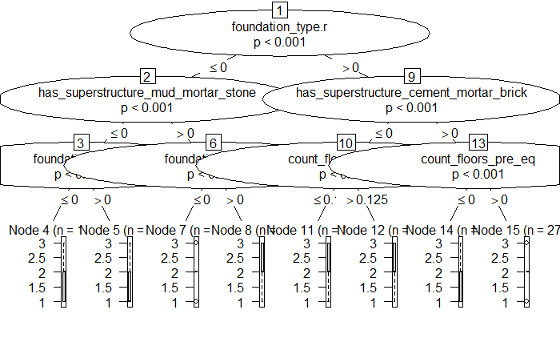

```r
best_criterion <- CART_pre_search_result[1,1]
best_split <- CART_pre_search_result[1,2]
best_depth <- CART_pre_search_result[1,3]

tree_control = ctree_control(mincriterion = best_criterion,
                             minsplit = best_split, maxdepth = best_depth)

CART_trn <- rbind(train, valid)
CART_best <- ctree(damage_grade ~ ., data = CART_trn, control = tree_control)
plot(CART_best)
```

```r
CART_pre_prediction <- predict(CART_best, newdata = test)
CART_pre_prediction <- ifelse(CART_pre_prediction > 2.5, 3,
                              ifelse(CART_pre_prediction > 1.5, 2, 1))
# Performance of the best tree
CART_pre_cm <- table(test$damage_grade , factor(CART_pre_prediction,
                                                levels = (1:3)))
CART_pre_cm
```

```
        1     2     3
  1  1410  4475     0
  2  1025 33422     0
  3    43 20226     0
```

```r
Perf_Table_CART <- matrix(0, nrow = 1, ncol = 2)
rownames(Perf_Table_CART) <- c("CART")
colnames(Perf_Table_CART) <- c("Accuracy", "BCR")

Perf_Table_CART[1,] <- perf_eval_multi(CART_pre_cm)
Perf_Table_CART
```

```
     Accuracy BCR
CART 0.574776   0
```

```r
Perf_Table_NN <- matrix(0, nrow = 1, ncol = 2)
colnames(Perf_Table_NN) <- c("ACC", "BCR")
rownames(Perf_Table_NN) <- c("best")

# Train ANN
train.input.nn <- train.k[,c(-69)]
train.target.nn <- class.ind(train.k[,c(69)])

# Valid the ANN
valid.input.nn = valid.k[,c(-69)]
valid.target.nn = class.ind(valid.k[,c(69)])

test.input.nn = test.k[,c(-69)]
test.target.nn = class.ind(test.k[,c(69)])

# Find the best number of hidden nodes in terms of BCR
# Candidate hidden nodes
nH <- seq(from=2, to=5, by=1)
nM <- c(50, 100, 150)
ra <- c(0.1, 0.3, 0.5)
val_perf <- matrix(0, 36, 5)
colnames(val_perf) <- c("nH", "nM", "range", "ACC", "BCR")

k = 1

for (i in 1:length(nH)) {
    cat("Training ANN: the number of hidden nodes:", nH[i], "\n")
    for (j in 1:length(nM)) {
        for (l in 1:length(ra)) {
            tmp_nnet <- nnet(train.input.nn, train.target.nn,
                             size = nH[i], range=ra[l],
                         decay = 5e-4, maxit = nM[j])
            prey <- predict(tmp_nnet, valid.input.nn)
            cfm <- table(max.col(valid.target.nn), factor(max.col(prey),
                                                     levels = (1:3)))

            val_perf[k,1] <- nH[i]
            val_perf[k,2] <- nM[j]
            val_perf[k,3] <- ra[l]
            # Record the validation performance
            val_perf[k,4:5] <- perf_eval_multi(cfm)
            k = k + 1
        }
    }
}
```

```
Training ANN: the number of hidden nodes: 2
Training ANN: the number of hidden nodes: 3
Training ANN: the number of hidden nodes: 4
Training ANN: the number of hidden nodes: 5
```

```r
val_perf
```

```
      nH  nM range   ACC       BCR
 [1,]  2  50   0.1 0.600 0.3242898
 [2,]  2  50   0.3 0.612 0.0000000
 [3,]  2  50   0.5 0.614 0.0000000
 [4,]  2 100   0.1 0.610 0.3079038
 [5,]  2 100   0.3 0.574 0.2331243
 [6,]  2 100   0.5 0.632 0.4573777
 [7,]  2 150   0.1 0.582 0.0000000
 [8,]  2 150   0.3 0.612 0.3359596
 [9,]  2 150   0.5 0.628 0.0000000
[10,]  3  50   0.1 0.614 0.0000000
[11,]  3  50   0.3 0.634 0.0000000
[12,]  3  50   0.5 0.642 0.3672776
[13,]  3 100   0.1 0.606 0.3564585
[14,]  3 100   0.3 0.620 0.4976568
```

[output cut: 22 more lines]

```r
ordered_val_perf <- val_perf[order(val_perf[,4], decreasing = TRUE),]
colnames(ordered_val_perf) <- c("nH", "nM", "ra", "ACC", "BCR")
ordered_val_perf
```

```
      nH  nM  ra   ACC       BCR
 [1,]  5 150 0.1 0.654 0.4654244
 [2,]  3 150 0.5 0.644 0.4705873
 [3,]  3  50 0.5 0.642 0.3672776
 [4,]  4  50 0.1 0.640 0.4489042
 [5,]  4 100 0.1 0.640 0.0000000
 [6,]  3 100 0.5 0.638 0.3763927
 [7,]  3  50 0.3 0.634 0.0000000
 [8,]  2 100 0.5 0.632 0.4573777
 [9,]  2 150 0.5 0.628 0.0000000
[10,]  4 150 0.3 0.628 0.0000000
[11,]  5  50 0.3 0.626 0.3847210
[12,]  3 100 0.3 0.620 0.4976568
[13,]  4 150 0.1 0.616 0.0000000
[14,]  2  50 0.5 0.614 0.0000000
```

[output cut: 22 more lines]

```r
best_nH <- ordered_val_perf[1,1]
best_nM <- ordered_val_perf[1,2]
best_ra <- ordered_val_perf[1,3]

# Test the ANN

best.nnet <- nnet(train.input.nn, train.target.nn, size = best_nH, range = best_ra,
                  maxit = best_nM)
# Performance evaluation
prey.best <- predict(best.nnet, test.input.nn)
tst_cm.best <- table(max.col(test.target.nn),
                     factor(max.col(prey.best), levels=(1:3)))
tst_cm.best
```

```
      1   2   3
  1   0  41  11
  2   0 200 183
  3   0  41 124
```

```r
Perf_Table_NN <- matrix(0, nrow = 1, ncol = 2)
rownames(Perf_Table_NN) <- c("MLR")
colnames(Perf_Table_NN) <- c("Accuracy", "BCR")


Perf_Table_NN[1,] <- perf_eval_multi(tst_cm.best)
Perf_Table_NN
```

```
    Accuracy BCR
MLR     0.54   0
```

```r
Perf.Table[1,] <- perf_eval_multi(MLR_cm)
Perf.Table[2,] <- perf_eval_multi(CART_pre_cm)
Perf.Table[3,] <- perf_eval_multi(tst_cm.best)
Perf.Table
```

```
               Accuracy       BCR
MLR            0.630000 0.4239695
CART           0.574776 0.0000000
ANN            0.540000 0.0000000
Bagging CART   0.000000 0.0000000
Bagging ANN    0.000000 0.0000000
Random Forests 0.000000 0.0000000
AdaBoost       0.000000 0.0000000
GBM            0.000000 0.0000000
```

###아래 질문들에 대해서는 Base Learner가 CART와 ANN인 경우 [Q1]에서 선택된 hyperparameter를 사용하여 실행하고 그 결과를 이용하여 답하시오.

### [Q2] CART의 Bagging 모델을 Bootstrap의 수를 30부터 30단위로 300까지 증가시 키 면서 분류 정확도를 평가해보시오. 최적의 Bootstrap 수는 몇으로 확인되는가? 이 모델은 단일 모형과 비교했을 때 성능의 향상이 있는가?

```r
ordered_perf_bagging_CART
```

```
        ACC       BCR bootstrap
 [1,] 0.650 0.3650604       270
 [2,] 0.650 0.3578956        30
 [3,] 0.646 0.3550032       150
 [4,] 0.658 0.3512942       180
 [5,] 0.664 0.3480803        60
 [6,] 0.658 0.3468416       240
 [7,] 0.652 0.3433075       210
 [8,] 0.638 0.3357246       300
 [9,] 0.654 0.3340292       120
[10,] 0.656 0.3318539        90
```

### [Q3] Random Forest 모델의 Tree의 수를 30부터 30단위로 300까지 증가시키면서 분류 정확도를 평가하고 다음 물음에 답하시오. 학습 과정에서는 변수의 중요도가 산출되도록 학습하시오.

```r
ordered_perf_RF
```

```
        ACC       BCR bootstrap
 [1,] 0.660 0.3950998       180
 [2,] 0.660 0.3915716        90
 [3,] 0.680 0.3912169       210
 [4,] 0.672 0.3892681       120
 [5,] 0.672 0.3845284       150
 [6,] 0.670 0.3824156       300
 [7,] 0.656 0.3790567        30
 [8,] 0.658 0.3673807        60
 [9,] 0.668 0.3648142       270
[10,] 0.676 0.3618408       240
```

```r
Perf.Table[6,]
```

```
 Accuracy       BCR
0.7033333 0.4954891
```

#### [Q3-2] 최적의 Tree 수를 기준으로 이 데이터셋에 대해서는 CART Bagging과 Random Forest 중에서 더 높은 분류 정확도를 나타내는 모형은 무엇인가?

정확도 기준으로 최적 모형에서 랜덤 포레스트 모델의 정확도가 더 높다. Random Forest가 해당 데이터셋에서는 다양한 트리를 많이 구성하면서 더 나은 성능을 보인다. 반면, 정확도의 차이가 매우 크게 나지 않는다. 배깅도 여러 트리모델을 구성하여 나쁘지 않은 성능을 보여준다.

[output not shown]

```r
Perf.Table[4,] <- ordered_perf_bagging_CART[1,1:2]
Perf.Table[c(4,6),]
```

```
                Accuracy       BCR
Bagging CART   0.6500000 0.3650604
Random Forests 0.7033333 0.4954891
```

#### [Q3-3] 각 Tree의 수(Bootstrap의 수)마다 CART Bagging 모형과의 분류 정확도를 비교할 수 있는 그래프를 도시하시오. Tree의 수는 CART Bagging과 Random Forest는 성능 차이에 영향을 미친다고 볼 수 있는가?

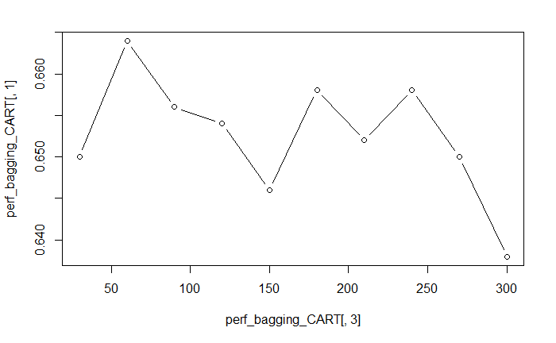

```r
plot(perf_bagging_CART[,3], perf_bagging_CART[,1], type = 'b')
```

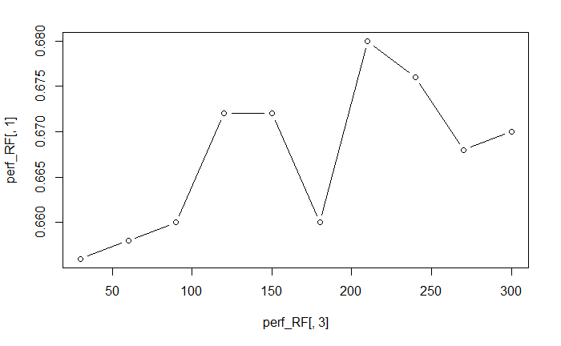

```r
plot(perf_RF[,3], perf_RF[,1], type = 'b')
```

### [Q4] [Q1]에서 찾은 최적의 hyperparameter를 이용하여 ANN 단일모형을 30번 반복하여 테스트 정확도를 평가해보시오. Accuracy와 BCR의 평균 및 표준편차를 기록하시오.

```r
mean(perf_Q4[,1]); mean(perf_Q4[,2]); sd(perf_Q4[,1]); sd(perf_Q4[,1])
```

```
[1] 0.595
[1] 0.4258616
[1] 0
[1] 0
```

### [Q5] ANN Bagging 모델 에 대해 다음 물음에 답하시오.

#### [Q5-1] Bootstrap의 수를 30부터 30단위로 300까지 증가시키면서 각 Boostrap 수마다 30회 반복 수행을 실시하 여 Accuracy와 BCR의 평균 및 표준편차를 각각 기록하시오.

|  | mean(ACC) | mean(BCR) | sd(ACC) | sd(BCR | bootstrap |
| --- | --- | --- | --- | --- | --- |
| 1 | 0.6238333 | 0.3158892 | 0.008443524 | 0.022843182 | 30 |
| 2 | 0.6247778 | 0.3052590 | 0.006398835 | 0.020292651 | 60 |
| 3 | 0.6244444 | 0.3045269 | 0.004938963 | 0.015637788 | 90 |
| 4 | 0.6238889 | 0.3084212 | 0.005745785 | 0.011142408 | 120 |
| 5 | 0.6267778 | 0.3055451 | 0.004309246 | 0.011455809 | 150 |
| 6 | 0.6264444 | 0.3053872 | 0.005210756 | 0.009021861 | 180 |
| 7 | 0.6248889 | 0.3056000 | 0.003444506 | 0.007555125 | 210 |
| 8 | 0.6257222 | 0.3062588 | 0.004075046 | 0.006651817 | 240 |
| 9 | 0.6250000 | 0.3055172 | 0.003914801 | 0.009049665 | 270 |
| 10 | 0.6233333 | 0.3084322 | 0.004440356 | 0.009142936 | 300 |

```r
cl <- makeCluster(4) # the number of cores
registerDoParallel(cl)

# Bagging Training
perf_bagging <- matrix(0, 10, 5)
colnames(perf_bagging) <- c("mean(ACC)", "mean(BCR)", "sd(ACC)", "sd(BCR)", "bootstrap")

tmp_perf_Q5 <- matrix(0, 30, 2)

nb = seq(240,300, by=30)

k = 8
for (i in nb){
    for (j in 1:30) {
        Bagging.ANN.model <- avNNet(train.input.nn, train.target.nn, size = best_nH, decay = 5e-4,
                            repeats = i, bag = TRUE, allowParallel = TRUE, trace = TRUE)
        Bagging.ANN.prey <- predict(Bagging.ANN.model, newdata = test.input.nn)
        Bagging.ANN.cfm <- table(max.col(test.target.nn), factor(max.col(Bagging.ANN.prey), levels = (1:3)))

        tmp_perf_Q5[j,1:2] <-  perf_eval_multi(Bagging.ANN.cfm)
        j <- j + 1
    }

    perf_bagging[k,1] <- mean(tmp_perf_Q5[,1])
    perf_bagging[k,2] <- mean(tmp_perf_Q5[,2])
    perf_bagging[k,3] <- sd(tmp_perf_Q5[,1])
    perf_bagging[k,4] <- sd(tmp_perf_Q5[,2])
    perf_bagging[k,5] <- i
    k = k + 1
}


perf_bagging
ordered_perf_bagging <- perf_bagging[order(perf_bagging[,2], decreasing = TRUE),]
ordered_perf_bagging
```

#### [Q5-2] 최적의 Bootstrap 수는 몇으로 확인되는가?

최적의 숫자는 BCR 기준으로 30, ACC 기준으로 150으로 확인된다.

### [Q6] Adaptive Boosting(AdaBoost)에 대해 다음 물음에 답하시오.

### [Q6-1] Hyperparameter 후보 값들을 명시하고, Validation dataset을 통해 최적의 hyperparameter 값을 찾아보시오.

하이퍼파라미터 후보 - 반복수(nb) : 10부터 10 단위로 100까지, 총 10개 - 비율(bag.frac) : 0.5, 0.7, 9.9

최적값 : nb = 70 , bag.frac = 0.5

|  | nb | ratio | ACC | BCR |
| --- | --- | --- | --- | --- |
| [1,] | 70 | 0.5 | 0.690 | 0.5106433 |
| [2,] | 80 | 0.5 | 0.650 | 0.5058548 |
| [3,] | 90 | 0.5 | 0.662 | 0.4967987 |
| [4,] | 60 | 0.5 | 0.662 | 0.4952254 |
| [5,] | 70 | 0.7 | 0.666 | 0.4872120 |
| [6,] | 100 | 0.7 | 0.658 | 0.4845569 |
| [7,] | 50 | 0.5 | 0.672 | 0.4829198 |
| [8,] | 60 | 0.7 | 0.670 | 0.4752001 |
| [9,] | 90 | 0.7 | 0.632 | 0.4666861 |
| [10,] | 100 | 0.5 | 0.670 | 0.4637739 |

#### [Q6-1] 최적의 hyperparameter 값을 이용하여 AdaBoost 모델을 학습한 뒤, Test dataset에 적용하여 먼저 구축된 모델들과 분류 성능을 비교해보시오.

|  | Accuracy | BCR |
| --- | --- | --- |
| MLR | 0.6216667 | 0.3877011 |
| CART | 0.5747760 | 0.0000000 |
| ANN | 0.6183333 | 0.3979824 |
| Bagging CART | 0.6540000 | 0.3179984 |
| Bagging ANN | 0.6566667 | 0.3651469 |
| Random Forests | 0.6700000 | 0.4174893 |
| AdaBoost | 0.6300000 | 0.3685614 |

```r
ordered_ADA_perf
```

```
       nb ratio   ACC       BCR
 [1,]  70   0.5 0.690 0.5106433
 [2,]  80   0.5 0.650 0.5058548
 [3,]  90   0.5 0.662 0.4967987
 [4,]  60   0.5 0.662 0.4952254
 [5,]  70   0.7 0.666 0.4872120
 [6,] 100   0.7 0.658 0.4845569
 [7,]  50   0.5 0.672 0.4829198
 [8,]  60   0.7 0.670 0.4752001
 [9,]  90   0.7 0.632 0.4666861
[10,] 100   0.5 0.670 0.4637739
[11,]  80   0.7 0.660 0.4633120
[12,]  80   0.9 0.636 0.4552658
[13,]  40   0.9 0.660 0.4520065
[14,]  30   0.7 0.620 0.4450479
```

[output cut: 16 more lines]

```r
Perf.Table
```

```
                Accuracy       BCR
MLR            0.6216667 0.3877011
CART           0.5747760 0.0000000
ANN            0.6183333 0.3979824
Bagging CART   0.6540000 0.3179984
Bagging ANN    0.6566667 0.3651469
Random Forests 0.6700000 0.4174893
AdaBoost       0.6300000 0.3685614
GBM            0.0000000 0.0000000
```

### [Q7] Gradient Boosting Machine(GBM)에 대해 다음 물음에 답하시오.

#### [Q7-1] Hyperparameter 후보 값들을 명시하고, Validation dataset을 통해 최적의 hyperparameter 값을 찾아보시오.

하이퍼파라미터 후보 - ntree : 50부터 50 단위로 500까지, 총 10개 - shrinkage : 0.01, 0.02, 0.03 - bag.frac : 0.4, 0.5 - ntraing : 100부터 100 단위로 500까지, 총 5개

최적값 : nb = 350 , shrinkage = 0.01, bag.frac = 0.4, nTrain = 500

|  | ntree | shirnkage | bag.fraction | nTrain | ACC | BCR |
| --- | --- | --- | --- | --- | --- | --- |
| [1,] | 350 | 0.01 | 0.4 | 500 | 0.606 | 0.8454976 |
| [2,] | 100 | 0.03 | 0.5 | 500 | 0.604 | 0.7766636 |
| [3,] | 150 | 0.02 | 0.5 | 400 | 0.604 | 0.7766636 |
| [4,] | 400 | 0.01 | 0.5 | 300 | 0.618 | 0.7663094 |
| [5,] | 450 | 0.01 | 0.5 | 300 | 0.618 | 0.7568195 |
| [6,] | 250 | 0.03 | 0.4 | 400 | 0.654 | 0.7124357 |
| [7,] | 200 | 0.03 | 0.5 | 500 | 0.630 | 0.7053713 |
| [8,] | 450 | 0.03 | 0.4 | 100 | 0.612 | 0.6866672 |
| [9,] | 300 | 0.03 | 0.5 | 500 | 0.658 | 0.6766425 |
| [10,] | 450 | 0.02 | 0.5 | 500 | 0.660 | 0.6719766 |

#### [Q7-2] 최적의 hyperparameter 값을 이용하여 GBM 모델을 학습(변수의 중요도가 산출되도록 학습)한 뒤, Test dataset에 적용하여 먼저 구축된 모델들과 분류 성능을 비교해보시오.

앙상블 모델에서는 예측에서 한 쪽 클래스로 쏠리는 경우가 발생하지 않을줄 알았는데, GBM모델의 결과가 모두 2로 예측되어 BCR=0으로 산출되었다. 이에 따라 정확도도 class 2의 비율은 0.62로 계산되었다. GBM 모델은 분류 성능에 있어서 최악의 모델이 되었다. 그 이유는 원래의 데이터가 불균형하여 최적 파라미터를 선정할 때, 영향을 미쳐서 이러한 결과가 나온 것 같다.

#### [Q7-3] 산출된 변수의 중요도를 해석해보고, Random Forest 모델에서 산출된 주요 변수와 비교해보시오.

```r
ntree <- seq(from=50, to=500, by=50)
shrink <- c(0.01, 0.02, 0.03)
bagfrac <- c(0.4, 0.5)
ntrn <- seq(from= 100, to= 500, by=100)

GBM_perf <- matrix(0, 300, 6)
colnames(GBM_perf) <- c("ntree", "shirnkage", "bag.fraction", "nTrain" ,"ACC", "BCR")

k = 1
for (i in 1:length(ntree)) {
    for (j in 1:length(shrink)) {
        for (l in 1:length(bagfrac)) {
            for (p in 1:length(ntrn)) {
                GBM.model <- gbm.fit(train.k[,1:68], train.k[,69], distribution = "gaussian",
                     n.trees = ntree[i], shrinkage = shrink[j], bag.fraction = bagfrac[l], nTrain = ntrn[p])

                GBM.prey <- predict(GBM.model, valid.k[,1:68], type = "response")
                GBM.prey <- round(GBM.prey)
                GBM.cfm <- table(GBM.prey, valid.k$damage_grade)

                GBM_perf[k,1] <- ntree[i]
                GBM_perf[k,2] <- shrink[j]
                GBM_perf[k,3] <- bagfrac[l]
                GBM_perf[k,4] <- ntrn[p]
                GBM_perf[k,5:6] <- perf_eval_multi(GBM.cfm)
                k=k+1
            }
        }
    }
}

ordered_GBM_perf <- GBM_perf[order(GBM_perf[,6], decreasing = TRUE),]
ordered_GBM_perf[1:10, ]


best_ntree <- ordered_GBM_perf[1,1]
best_shrinkage <- ordered_GBM_perf[1,2]
best_bag.frac <- ordered_GBM_perf[1,3]
best_nTrain <- ordered_GBM_perf[1,4]
```

```r
GBM.model <- gbm.fit(train.k[,1:68], train.k[,69], distribution = "gaussian",
                     n.trees = 350, shrinkage = 0.01,
                     bag.fraction = 0.4, nTrain = 500)
summary(GBM.model)
GBM.prey <- predict(GBM.model, test.k[,1:11], type = "response")
GBM.prey <- round(GBM.prey)
GBM.cfm <- table(test.k$damage_grade,factor(GBM.prey, levels=1:3))

Perf.Table[8,] <- perf_eval_multi(GBM.cfm)
Perf.Table
```

```r
summary(GBM.model)
```

[output not shown]

### [Q8] 총 여덟 가지의 모델(Multinomial logistic regression, CART, ANN, CART Bagging, ANN Bagging, Random Forest, AdaBoost, GBM) 중 BCR 관점에서 가장 우수한 분류 정확도를 나타내는 모형은 무엇인가?

BCR 관점에서 성능을 평가하면, CART와 GBM은 평가 대상에서 제외된다. 모델링 과정 중 제대로 분류가 되지 않아 BCR=0으로 나타났기 때문이다. 랜덤포레스트가 0.42로 가장 성능이 우수하고, Bagging CART가 0.32로 가장 성능이 열등하다. 랜덤포레스트가 Computational Cost가 아주 커서 오래 걸리는 모델이지만 많은 트리를 사용하여, 모델의 다양성을 만들어, 좋은 성능의 모델로 선정 되었다.

|  | Accuracy | BCR |
| --- | --- | --- |
| MLR | 0.6216667 | 0.3877011 |
| CART | 0.5747760 | 0.0000000 |
| ANN | 0.6183333 | 0.3979824 |
| Bagging CART | 0.6540000 | 0.3179984 |
| Bagging ANN | 0.6566667 | 0.3651469 |
| Random Forests | 0.6700000 | 0.4174893 |
| AdaBoost | 0.6300000 | 0.3685614 |
| GBM | 0.6166667 | 0.0000000 |

```r
Perf.Table
```

### [Extra Question] 이 데이터셋은 아래 표와 같이 Class 2 > Class 3 > Class 1 순으로 높은 비중을 차지하고 있으며, 범주의 불균형이 상당한 수준이다. [Q8]에서 선정된 가장 우수한 모델(알고리즘 및 hyperparameter)에 대해서 데이터 전처리 관점에서 불균형을 해소하여 분류 성능을 향상시킬 수 있는 아이디어를 제시하고 실험을 통해 검증해보시오.

가장 이상적인 경우는 범주의 불균형이 존재하지 않는 경우 그대로 모델링을 하면 된다. 하지만, 이 데이터셋과 같이 범주의 불균형이 존재하는 경우 bias를 약간 포기하고, 불균형을 해소하는 기법들이 존재한다. 가장 낮은 범주인 Class 1의 데이터를 복제해서 균형을 맞추는 샘플링 방법, 가장 많은 범주인 Class 2의 데이터를 일부 제거해서 균형을 맞추는 방법이 있다. 또는 각각의 범주에서 같은 개수 만큼의 데이터를 랜덤으로 뽑아서 데이터를 전처리하는 방법이 있다.

이러한 경우 장점은 BCR을 성능 지표로 쓸 때, 앞선 문항에서 특정 클래스로 예측되는 데이터가 0개인 경우를 최소화 할 수 있다. 특정 클래스의 예측치가 0이 되는 경우 BCR=0이 되어 성능 지표로 사용하기 곤란하게 되지만 불균형을 해소하면 이러한 걱정을 하지 않을 수 있다. 반면, 원본 데이터를 우리의 마음대로, 임의로 수정을 하는 것이기 때문에 분류 성능이 편향되어 있다는 사실을 인지하고 모델링을 진행해야 한다.

데이터셋에서 class 1, class 2, class 3에 해당하는 데이터를 각각 1000개 씩 추출하는 샘플링을 통해 모델의 성능을 측정해보자. 8번에서 가장 우수했던 랜덤포레스트 모델을 사용하여 성능을 측정한 결과, 정확도는 0.66, BCR은 0.66이 나왔다. 정확도 측면에서는 1퍼센트 감소했으나 BCR가 매우 높은 향상을 보여준다. BCR 지표로 성능을 평가하는 경우 불균형을 해소하여 성능이 향상되었다. 반면, 이 값은 bias가 되었을 가능성이 높다는 점을 생각해야한다.

```r
perf_eval_multi(RF.cfm.sa)
```

```
[1] 0.6602028 0.6587560
```